# About

## 1) Introduction

In 2011, one of the biggest humanitarian crises in recent human history erupted when the Syrian Civil war began. The conflict led to the death of hundreds of thousands, the displacement of millions, and an economic toll in the tens of billions (Altındağ and Kaushal 2021). It is safe to say that the Syrian economy will take years to recover, and the government has firmly lost the faith of its people. The conflict spread in the region, with neighboring countries feeling the brunt of refugee movements. One of these countries is Lebanon.

At its core, this project addresses the economic impact of mass migration on a neighboring nation’s economy. In particular, the following analysis attempts to take a deeper look at the impact of the Syrian refugee crisis on the general economy of Lebanon.

Lebanon is the biggest host of refugees per capita in the world, with recent UNHCR estimates placing 1 refugee to each 4 citizens (World Bank 2013 Executive Summary). This has led to uproar from citizens claiming a disruption in safety resulting from increases in refugee concentrations.

My research question will be the as follows: how did the Syrian refugee crisis that started in 2011 impact Lebanon’s economy?

This topic is of particular interest to me. As a Lebanese citizen who has seen the mistreatment of refugees in my own country under the guise of national economic prosperity, this topic is near and dear. I would like the opportunity to explore this relationship myself, far from biased media outlets and politics. This topic is far from being merely controversial in the Middle East. Migration and its impact on local economies has taken a front stage in global politics, specifically that of the Global North. Extremist stances on migration have driven voting patterns and major elections such as in Argentina, the Netherlands, Portugal, and France.

## 2) Literature Review

In order to back my analysis, I will be relying on several pieces of literature. The articles below acutely assess various impacts of refugees on host countries’ economies. They generally agree that refugees mostly have positive impacts on host countries’ economies. These articles exhibit significant increases in wages in host countries following refugee inflows. They also show little changes in security patterns in host countries (Daher 2023). In particular, while the World Bank executive summary highlights the sheer scale at which refugees have moved into Lebanon throughout the 2010s, other literature has shown that under the right circumstances, refugees may even be beneficial for a country’s economic growth prospects (Tumen 2016). This is partially because refugees are often more willing to work for cheaper and thus allow for more labor at cheaper costs, a salient point for the Lebanese economy. The literature also appears to show that refugees have little to no impact on security levels in a country, as shown in Onur et. al ((Altındağ and Kaushal 2021)). In their paper, the authors clearly show that refugees do not cause spikes in crime (at least not in major cities), and do not appear to burden a nation’s budget allocation for police departments. This finding is relevant to our analysis, as our paper deals with the perceived riskiness of a country, which national security clearly factors into.

In particular, this project goes deeper by looking at two other factors. First, we assess the impact of Syrian refugee entry on the perceived riskiness of the Lebanese economy. In particular, this riskiness will be modeled by the international interest rates that international investors are willing to offer the central bank of Lebanon for its bonds. Second, this project also differentiates itself by assessing the impact of Syrian refugee entry into the country on the lower, middle, and upper classes of the Lebanese population instead of looking at aggregate measures.

World Bank Executive Summary, The World Bank Group, 2013, https://www.worldbank.org/content/dam/Worldbank/document/MNA/LBN-ESIA%20of%20Syrian%20Conflict-%20EX%20SUMMARY%20ENGLISH.pd

Why Syrian Refugees in Lebanon are a crisis within a crisis, Brookings Institution, 2021, https://www.brookings.edu/articles/why-syrian-refugees-in-lebanon-are-a-crisis-within-a-crisis/

Altındağ Onur, and Kaushal Neeraj. 2021. Do refugees impact voting behavior in the host country? evidence from syrian refugee inflows to turkey. *Public Choice*186, (1-2) (01): 149-178, https://proxy.library.upenn.edu/login?url=https://www.proquest.com/scholarly-journals/do-refugees-impact-voting-behavior-host-country/docview/2481412237/se-2 (accessed May 1, 2024).

(Altındağ and Kaushal 2021)

Tumen, Semih. 2016. The economic impact of syrian refugees on host countries: Quasi-experimental evidence from turkey. *The American Economic Review* 106, (5) (05): 456-460, https://proxy.library.upenn.edu/login?url=https://www.proquest.com/scholarly-journals/economic-impact-syrian-refugees-on-host-countries/docview/1788238326/se-2 (accessed May 1, 2024).

(Tumen 2016)

Edward, Taylor J. 2016. Economic Impact of Refugees. *Cornell University*. [**https://doi-org.proxy.library.upenn.edu/10.1073/pnas.1604566113**](https://doi-org.proxy.library.upenn.edu/10.1073/pnas.1604566113)

(Taylor et al. 2016)

## 3) Hypothesis

My initial hypothesis is that Syrian refugees would not have discouraged aggregate economic growth in Lebanon and do not impact the aggregate risk profile of Lebanon but would likely have impacted the wealth of the Lebanese income distribution. To clarify, I have distilled my initial research question regarding the economic impact of refugee on the host country’s economy into two separate hypotheses. First, I hypothesize that an increase in the inflow of refugees does not impact interest rates offered to Lebanon. Second, I hypothesize that an increase in the inflow of refugees does not impact GDP per Capita.

I will start by addressing the first hypothesis, regarding the impact of refugee inflow on interest rates.

Interest rates reflect the cost of servicing a sovereign debt. One a country (or, in fact, any entity) borrows from a lender, there is a risk that it will default on its loans in the future. The interest rates reflect the probability of a default, with higher interest rates reflecting the possibility that a country is more likely to default. A myriad of factors may make it more likely that a country defaults on its future payments, such as wars, corruption, internal political crises, or even potentially refugee crises. Previous papers (such as (Tumen 2016)) have highlighted that refugees, in aggregate, do not decrease the credit-worthiness of a country’s debt outlook. This is because refugees are often provided little aid from host countries. Instead, it is the host country that is often provided aid by international organizations and foreign countries in order to care for their refugees. These aid packages often look like low-interest loans. Lebanon is no different, with the EU recently announcing a 1 billion USD aid package to the country in order to act as a gateway to Europe. As a result, I hypothesize that refugees do not decrease a nation’s creditworthiness.

Now I will address the second hypothesis, regarding the impact of refugee inflow on GDP per Capita.

First, looking at the relationship between Syrian refugee inflow and GDP per capita, refugees often constitute a source of cheap labor, reducing costs for companies and other workplaces, increasing these institutions’ reach and profits. With an increase in corporate profits comes and increase in consumption, investment, and government revenue through taxes, all three of which are components of a nation’s gross domestic product. Additionally, as is reflected in the Center for Strategic International Studies’ research on the crisis, not only did Syrian refugees provide for cheap labor, they also consumed goods and other services, often through income generated through World Bank or UNHCR donations and aids packages. This would likely create further economic activity, and thus a higher GDP, and thus a higher GDP per Capita for a fixed population. (Taylor et al. 2016)

Second, while the Syrian refugee inflow provides for cheaper labor, it also lowers the wage that Lebanese workers would obtain as markets get more competitive (which is a likely cause of the outrage experienced). As a result, it’s likely that some Lebanese families that worked in manual workplaces found themselves either losing their jobs or accepting pay cuts (Brooking INstitutions, 2011). In fact, in their paper, Brookings mentions the possibility of varying impact of refugee movements across income categories. In other words, refugee entry would more severely impact people in lower income groups than the top 1% of earners, as they would likely be competing for different jobs.

## 4) Research Design

### a) Data

The dataset at my disposal is a combination of data from the World Development Indicators, estimations from Trading Economics, and data on international interest rates offered to the Central bank of Lebanon (which will be used as a measure of economic stability in the country).

The sample consists of monthly data of the following variables:

1) Estimated Refugee Entry: an estimation of monthly Syrian refugee entries into Lebanon. This is the main independent variable of analysis. These data points are estimates generated by the World Bank and represent the World Bank’s best estimates as to inflows of Syrian refugees into Lebanon. Note that these data points will be lagged by 3 months in order to account for the fact that refugee entry does not automatically affect the fluctuations in GDP and interest rates. Instead, as GDP metrics ar issued quarterly, refugee entry would take about 3 months on average to potentially impact change that will be reflected in macro-metrics.

2) International Interest Rates: the interest rates imposed by the international community on sovereign bonds issued by the Lebanese central bank. This will be one of the dependent variables used and is intended as a proxy for Lebanon’s creditworthiness, as investors determine interest rates based off of the potential to default.

3) Lebanon Growth Rate: A metric of the GDP growth rate in Lebanon. This will be used as a control.

4) Syria Growth Rate: A metric of the GDP growth rate in Syria. This will be used as a control.

5) GDP Per Capita: A metric of the GDP per Capita in Lebanon. This will be one of the dependent variables used and is intended as a proxy for the perceived wealth, as countries with higher GDP per Capita tend to have wealthier people on average.

6) Top 20% Wealth: A metric of the percentage of wealth owned by the top 20% of earners in Lebanon. This will be one of the dependent variables used and is intended as a measure of wealth distribution.

7) Financial Accounts: A metric of the net financial flows coming in and out of Lebanon. This will be used as a control, as it could potentially be a confounder. The logic here is that a large financial can often create the perception of wealth or creditworthiness without necessarily having macro factors to back it up. As a result, financial accounts could be a mediator variable, as refugee inflow could impact financial accounts given the levels of aid received, and financial accounts could subsequently impact GDP per Capita and interest rates. As a result, we will include financial accounts as a control in our models.

We will build a summary statistics table in what follows.

Summary Statistics Table

Mean, Range, and Standard Deviation of Each Variable

| Variable | Mean | Range | SD |
| --- | --- | --- | --- |
| Estimated Refugee Entry | 13553.125000 | 30560.00 | 9740.1010101 |
| International Interest Rates | 4.689583 | 3.30 | 0.9960004 |
| Lebanon Growth Rate | 1.168750 | 0.50 | 0.1339359 |
| Syria Growth Rate | -14.766667 | 34.40 | 13.4171902 |
| GDP Per Capita | 8045.481250 | 2030.70 | 544.8495680 |
| Top 20% Wealth (in %) | 48.595833 | 12.20 | 3.6140364 |
| Financial Accounts (in USD Millions) | 771.023333 | 3913.33 | 760.7004730 |

### b) Regression Models

Let GDPL and GDPS be Lebanon and Syria’s GDP growth respectively, i is the international interest rates, and ref the refugee inflow. Also, let GDPPerCap be the GDP Per Capita in Lebanon, and FA be the financial account.

We will build out two separate regression models.

The first regression model associates international interest rates to refugee inflow, and would look as follows:

i = $\alpha$ + $\beta$ ref + $\gamma1$ GDPS + $\gamma2$ GDPL + $\gamma3$ FA + e

where e represents the error term. Our hypothesis entails that $\beta$ is not significant, which we will find out once running the model, and assuming that all the regression assumptions are fulfilled. In particular, we assume no colliders are in the model (which is why we are working with the lagged Syrian growth as a variable), as well as the existence of different confounders (such as economic instability in the country which would be caused by syrian refugee inflow).

The second regression model associates international GPD Per Capita to refugee inflow, and would look as follows:

GDPPerCap = $\alpha$ + $\beta$ ref + $\gamma1$ GDPS + $\gamma2$ GDPL + $\gamma3$ FA + e

where e represents the error term. Our hypothesis entails that $\beta$ is either positive or negligible, which we will find out once running the model, and assuming that all the regression assumptions are fulfilled. In particular, we assume no colliders are in the model (which is why we are working with the lagged Syrian growth as a variable), as well as the existence of different confounders (such as economic instability in the country which would be caused by syrian refugee inflow).

There exist certain limitations to this analysis. First, this analysis only includes 48 data points. While fulfilling the necessary required number of observations for the Central Limit Theorem to apply, more data would certainly be preferable. Second, the data on refugee flows is merely estimates (albeit provided by the World Bank). Refugee flows are notoriously hard to measure especially at such granular levels. As a result, we acknowledge that these estimates might bias our results.

In addition, GDP Per Capita is an average metric. It does not accurately represent the experiences of a people. In other word, just because refugee inflow does not impact GDP Per Capita does not mean that people aren’t worse off as a result of an increase in the stock of refugee. In particular, income distribution matters a lot here, as a shift in wealth concentrations would not necessarily impact GDP Per Capita, but would certainly lead to an increase in the number of poor people. As a result, this is a confounder that we will be tackling in future sections.

### c) Findings

The graph below is a scatterplot of GDP per Capita (on the y-axis) versus refugee inflow (on the x-axis) at each frequency level. Note that the refugee entry variable has been lagged to better reflect its real impact on the dependent variable of interest.

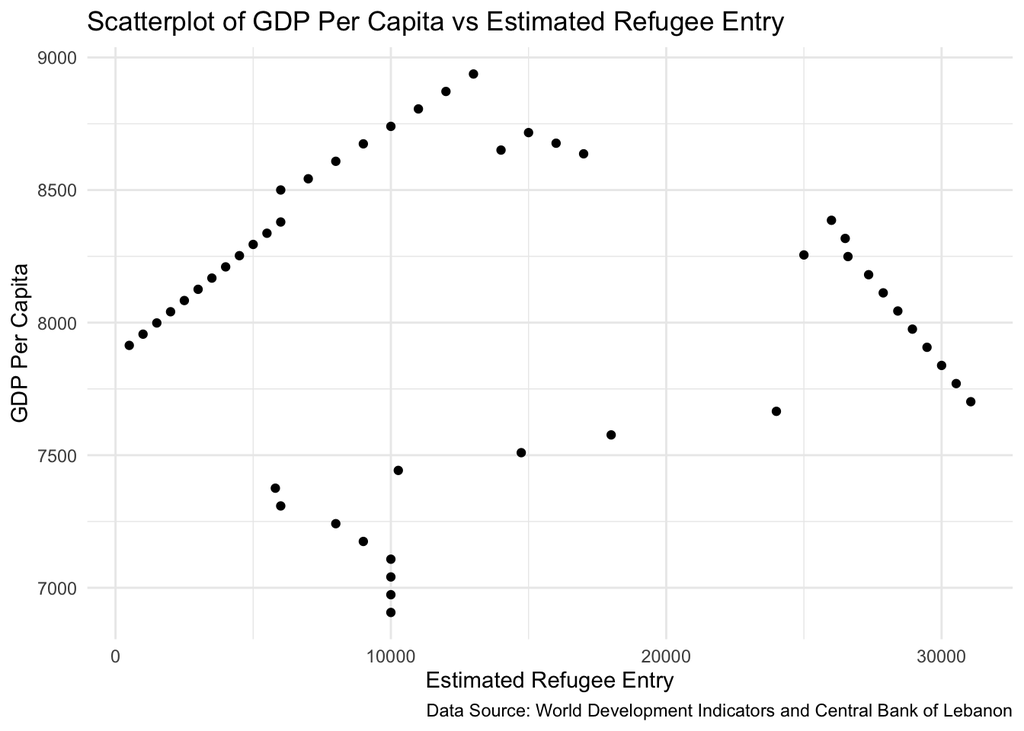

The graph below is a scatterplot of international interest rates (on the y-axis) versus refugee inflow (on the x-axis) at each frequency level. Note that the refugee entry variable has been lagged to better reflect its real impact on the dependent variable of interest.

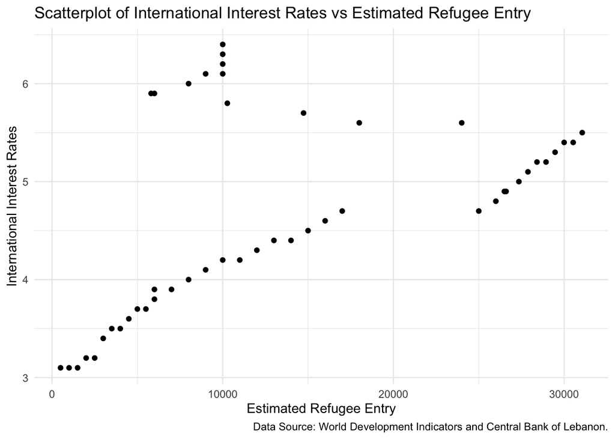

The two graphs above somewhat align with our initial hypothesis. On the one hand, the graph showcasing the association between estimated refugee entry and international interest rates does appear to show a positive relationship between the two variables. While far from causal at the moment, this graph seems to suggest that there is a perceived increase in risk associated with Lebanon’s sovereign debt that arises as a result of refugee entry. This could potentially be causal, i.e. more refugees entering the country could lead the government to have to undertake more debt, rendering its borrowing patterns less sustainable and thus more risky. On the other hand, this relationship could be caused by a confounder, such as the deterioration of the economic situation in Syria, one of Lebanon’s major trading partners. This would seem to contradict our hypothesis that an increase in refugee entry does not impact the Lebanese risk profile.

On the other hand, the graph showcasing the association between estimated refugee entry and GDP Per Capita does not appear to offer as concrete of a relationship. At the very beginning of the graph, there appears to be a somewhat positive relationship between the two variables, whereas this relationship seems to flip to a negative association at the very tail of the graph. This could mean that refugee entry only increases GDP Per Capita up to a certain cap, which would somewhat corroborate the observed patterns in the overall literature. Otherwise, it could also simply represent a lack of a relationship, which would also corroborate our hypothesis that refugee entry does not harm the aggregate welfare of citizens of a host country.

Below we run our first model, regressing international interest rates on several other variables.

|  | (1) |
| --- | --- |
| (Intercept) | -1.946 |
|  | 0.019 |
| Estimated Refugee Entry | 0.000 |
|  | 0.947 |
| Lebanon Growth Rate | 5.443 |
|  | <0.001 |
| Syria Growth Rate | -0.015 |
|  | 0.239 |
| Financial Accounts (in USD Millions) | 0.000 |
|  | 0.648 |
| Num.Obs. | 48 |
| R2 | 0.735 |
| R2 Adj. | 0.710 |
| AIC | 83.1 |
| BIC | 94.3 |
| Log.Lik. | -35.535 |
| F | 29.823 |
| RMSE | 0.51 |

Given the p-value of 0.947 associated with the estimated refugee entry, and the estimated effect of 0 that refugee entry has on international interest rates, we can assume that refugee entry has no impact on international interest rates. This validates our hypothesis that refugee fluctuations do not bear a significant impact on the risk profile of a country.

The second regression model associates international GPD Per Capita to refugee inflow, and would look as follows:

|  | (1) |
| --- | --- |
| (Intercept) | 11300.695 |
|  | <0.001 |
| Estimated Refugee Entry | -0.012 |
|  | 0.316 |
| Lebanon Growth Rate | -2916.457 |
|  | <0.001 |
| Syria Growth Rate | -24.707 |
|  | 0.009 |
| Financial Accounts (in USD Millions) | -0.056 |
|  | 0.533 |
| Num.Obs. | 48 |
| R2 | 0.525 |
| R2 Adj. | 0.481 |
| AIC | 716.3 |
| BIC | 727.5 |
| Log.Lik. | -352.143 |
| F | 11.899 |
| RMSE | 371.43 |

This model confirms our initial hypothesis that refugee inflow does not bear any harm to average wealth per capita, as the 0.316 p-value would suggest as well as the relatively small effect value of -0.012.

In sum, the effect of refugee inflows into Lebanon in both models is not only small (0 and -0.012 respectively), it is also not statistically significant given the p-values and standard deviations in question. This analysis confirms our initial hypothesis that refugee inflows does not in fact bear significant impact on international interest rates and GDP per Capita. What this means is that macro-factors appear to be relatively unimpacted by Syrian refugee inflow into Lebanon, as the country’s financial profile vis-a-vis international investors appears unharmed the the Lebanese output does not appear to be taking a hit at a per Capita level.

## 5) Empirical Extension

### a) Regression Model

As discussed above, the goal of this project is to assess the impact of refugee inflows in Lebanon on the economic welfare of individuals. While our previous analysis does claim that there is no impact on average wealth, distribution of wealth may occur as a result of refugee inflows. This is because refugees compete for lower paying jobs that are often manual or physical with other working class citizens. When more competition accrues and in the absence of adequate laws, it is likely that wages will fall for these already low paying jobs. As a result, lower or middle class individuals would make less money, while shareholders and business owners likely reap the benefits of lower labor costs. In order to investigate this relationship, I will rerun the model above on the top20 variable as the dependent variable, representing the concentration of wealth in the country’s richest 20%.

The model will look as follows:

top20 = $\alpha$ + $\beta$ ref + $\gamma1$ GDPS + $\gamma2$ GDPL + $\gamma3$ FA + e

where e represents the error term. Our hypothesis entails that $\beta$ is positive, which we will find out once running the model, and assuming that all the regression assumptions are fulfilled. In particular, we assume no colliders are in the model (which is why we are working with the lagged Syrian growth as a variable), as well as the existence of different confounders (such as economic instability in the country which would be caused by syrian refugee inflow).

### b) Findings

|  | (1) |
| --- | --- |
| (Intercept) | 29.036 |
|  | <0.001 |
| Estimated Refugee Entry | 0.000 |
|  | 0.404 |
| Lebanon Growth Rate | 15.307 |
|  | <0.001 |
| Syria Growth Rate | -0.158 |
|  | <0.001 |
| Financial Accounts (in USD Millions) | 0.000 |
|  | 0.987 |
| Num.Obs. | 48 |
| R2 | 0.763 |
| R2 Adj. | 0.741 |
| AIC | 201.4 |
| BIC | 212.6 |
| Log.Lik. | -94.680 |
| F | 34.689 |
| RMSE | 1.74 |

The model above provides a 0.404 p-value for the independent variable of interest, meaning that refugee inflows do not significantly impact wealth concentration in the top 20%. Additionally, the magnitude of the impact shown is a mere 0, meaning there is no impact to begin with. This allows us to rule out the possibility that refugee inflows change the distribution of wealth while keeping the average wealth intact. As a result, our previous finding is more robust. This is because our most recent model shows that refugee inflows do not impact wealth distribution, so not only do refugee inflows not have an impact on average metrics, they also do not change wealth distributions which could have potentially contributed to changes in perceived poverty. As a result, we can more confidently rule out the possibility that refugee inflows in Lebanon have led to an increase in perceived poverty.

## 6) Discussion and Policy Implications

In our analysis, we initially set out to gain a better understanding of the impact of Syrian refugee inflows into Lebanon on the economy of the country. We had previously hypothesized that Syrian refugee inflows into the country likely do not bear any impact on macro-variables prevalent over the economy of the country. In order to assess our hypothesis, we relied on World Bank and Central Bank data regarding various macroeconomic factors, most notably of which are interest rates (necessary to assess the riskiness of the Lebanese economy), GDP per Capita (necessary in order to determine the wealth level in the country), and refugee inflow data. After running our models, it appears that Syrian refugee inflows bear little to no impact on the state of the economy. In addition, in order to increase the robustness of our results, we have run a similar model on the income distribution in the country, pursuing the possibility that Syrian refugees might skew the overall wealth distribution while not necessarily impacting the average wealth level. Having run our model, it appears that refugee entry had little to not impact on income distribution, once again confirming that it does not appear as if the refugee crisis that has occurred in Lebanon for years now has had any major impact on wealth or perceived creditworthiness of the country. Instead, this study would suggest that the public outcry against refugees that has recently gained momentum appears to be misguided at best and manufactured by a corrupt government at worst. This paper would suggest that policies related to the deportation of refugees have little basis in economics and are instead founded on political preferences and opinions. Moving forward, policies that expel refugees back into Syria while conditions remain unsafe are likely in violation of the Geneva Convention and the non-refoulement principal. Instead, preferable policies would integrate refugees into the economy of the country and instead value them as humans with an unwavering right to self-determination and life. Such policies could include collaborations with the European Union in order to receive preferential rates for loans (as suggested in the recent EU package passed for Lebanon), as well as the United Nations to ensure the proper reorganization of refugee life in the country.

While we expect this analysis to have a reasonable level of internal validity, it is unlikely to be significantly externally valid, as this analysis is specific to Lebanon, and there remain too many unobserved variables across countries that are not controlled for in this analysis that would prevent reasonable extrapolation. Nevertheless, this paper may be added to the wealth of literature showcasing that refugees do not nefariously impact the economy of a country

## References

Altındağ, Onur, and Neeraj Kaushal. 2021. “Do Refugees Impact Voting Behavior in the Host Country? Evidence from Syrian Refugee Inflows to Turkey.” *Public Choice* 186: 149–78.

Daher, Ali. 2023. “The Syrian Refugee Crisis and Its Impact on Lebanon.” Master’s thesis.

Taylor, J Edward, Mateusz J Filipski, Mohamad Alloush, Anubhab Gupta, Ruben Irvin Rojas Valdes, and Ernesto Gonzalez-Estrada. 2016. “Economic Impact of Refugees.” *Proceedings of the National Academy of Sciences* 113 (27): 7449–53.

Tumen, Semih. 2016. “The Economic Impact of Syrian Refugees on Host Countries: Quasi-Experimental Evidence from Turkey.” *American Economic Review* 106 (5): 456–60.